# activ_2

HIDROLOGIA ESTATÍSTICA  
ATIVIDADE 2 – ESTATÍSTICA DESCRITIVA  
**Objetivos:** Aplicar os conceitos e ferramentas da estatística descritiva na análise de séries hidrológicas.  
**Descrição do trabalho:** Selecionar duas bacias hidrográficas. Para cada bacia hidrográfica selecionar uma série pluviométrica e uma série fluviométrica utilizando a base de dados da Agencia Nacional de Águas (ANA). Baixar as séries temporais médias em escala diária, mensal e anual para cada estação. As séries selecionadas devem ter no mínimo 30 anos de extensão sem falhas. Desenvolver os seguintes itens:

1. Estatística descritiva das séries de vazão em escala diária, mensal e anual. **OK**
2. Estatística descritiva das séries de precipitação em escala mensal e anual. **OK**
3. Apresentar gráficos utilizando a livraria “ggplot2” para apoiar a análise de dados:
- Gráfico de dispersão (Vazão vs precipitação)
- Histograma
- Polígono de frequência
- Box-plots das séries mensais
- Curva de permanência (Série de vazão media anual)
1. Fazer uma discussão crítica que compare a estatística descritiva estimada das variáveis observadas.
2. Apresentar o trabalho em formato artigo com os seguintes elementos: Resumo, Introdução, Métodos, Resultados, Conclusões. O corpo do documento deve ter no máximo 10 páginas. Utilizar anexos de figuras caso for necessário.

## Funções auxiliares

```python
import pandas as pd
# import numpy as np
# import matplotlib.pyplot as plt
# import seaborn as sns

import activ_2 as aux
```

```python
salvar = False
```

## Manipulação das séries

```python
file = 'org_geral.xlsx'
```

```python
df_tiririca = pd.read_excel(
    file, sheet_name='serie', usecols='A:C',
    header=0, index_col=0,
)

df_fazendinha = pd.read_excel(
    file, sheet_name='serie', usecols='U:W',
    header=0, index_col=0,
)
```

```python
files = [
    "flow_sjp.xlsx", "prec_sjp.xlsx",
    "flow_xgu.xlsx", "prec_xgu.xlsx",
]

desc_serie = [
    "Vazão SJP", "Precipitação SJP",
    "Vazão XGU", "Precipitação XGU",
]

df_dia = [0, 0, 0, 0, 0]
df_mes = [0, 0, 0, 0, 0]
df_ano = [0, 0, 0, 0, 0]

for file, title, i in zip(files, desc_serie, range(4)):
    print(title)
    _, _, _, _, _, df_dia[i], df_mes[i], df_ano[i] = aux.activ_2_stats(file)
```

```
Vazão SJP
Início da série: 1965-01-01
Fim da série: 2015-12-31
Anual
                         Valor Unidade
Tamanho                     51       -
Média                     2.87    m3/s
Desvio padrão             0.76    m3/s
Variância                 0.58   m6/s2
Primeiro quartil          2.45    m3/s
Mediana                   2.86    m3/s
Terceiro quartil          3.32    m3/s
Amplitude inter-quartil   0.87    m3/s
Máximo                    4.84    m3/s
Mínimo                    1.47    m3/s
Amplitude                 3.37    m3/s
Coeficiente de variação   26.0       %
Assimetria               0.415       -
Curtose                  0.346       -


Diário
                         Valor Unidade
Tamanho                  18599       -
Média                     2.87    m3/s
Desvio padrão             2.36    m3/s
Variância                 5.55   m6/s2
Primeiro quartil          1.32    m3/s
Mediana                   2.06    m3/s
Terceiro quartil          3.66    m3/s
Amplitude inter-quartil   2.34    m3/s
Máximo                   21.17    m3/s
Mínimo                    0.38    m3/s
Amplitude                20.79    m3/s
Coeficiente de variação   82.0       %
Assimetria               2.163       -
Curtose                  6.228       -


Mês: 1
```

[output cut: 963 more lines]

```
                         Valor Unidade
Tamanho                     30       -
Média                    10.52    m3/s
Desvio padrão             1.46    m3/s
Variância                 2.14   m6/s2
Primeiro quartil           9.3    m3/s
Mediana                   10.6    m3/s
Terceiro quartil         11.42    m3/s
Amplitude inter-quartil   2.12    m3/s
Máximo                   13.66    m3/s
Mínimo                    7.41    m3/s
Amplitude                 6.25    m3/s
Coeficiente de variação   14.0       %
Assimetria              -0.159       -
Curtose                 -0.344       -
```

## Geração de gráficos

### Gráfico de dispersão

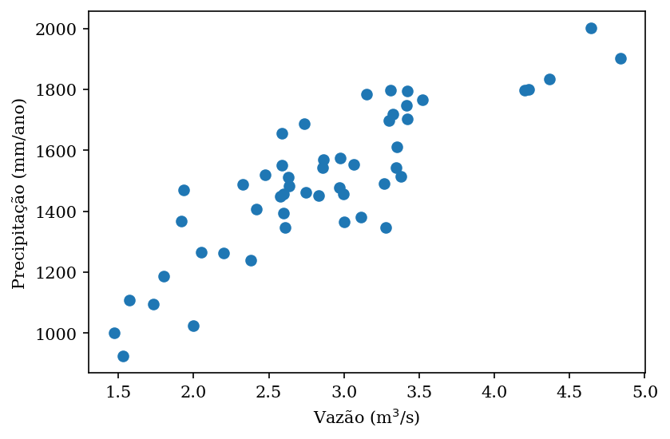

```python
fig, ax = plt.subplots()

ax.scatter(df_ano[0]["data"], df_ano[1]["data"] * 365)
ax.set_xlabel("Vazão (m$^3$/s)")
ax.set_ylabel("Precipitação (mm/ano)")

if salvar:
    fig.savefig("figures/scatter_sjp.png", format="png", dpi=300)
plt.show()
```

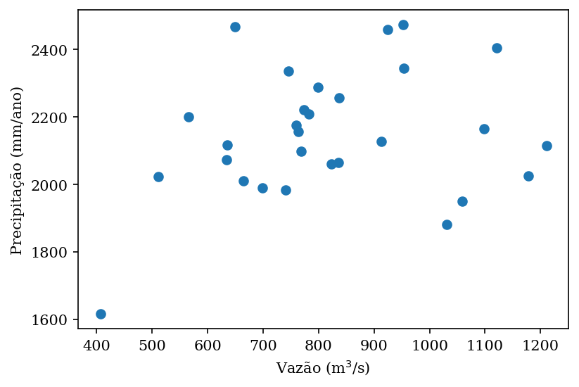

```python
fig, ax = plt.subplots()

ax.scatter(df_ano[2]["data"].iloc[1:-1], df_ano[3]["data"].iloc[1:-1] * 365)
ax.set_xlabel("Vazão (m$^3$/s)")
ax.set_ylabel("Precipitação (mm/ano)")

if salvar:
    fig.savefig("figures/scatter_sjp.png", format="png", dpi=300)
plt.show()
```

### Histograma

```python
serie_anual = df_ano[0]
N = serie_anual.shape[0]
NC = round(1 + 3.3 * np.log10(N))  # Sturges
```

```python
counts, bins_pol = np.histogram(serie_anual["data"], bins=NC)
```

```
[]
```

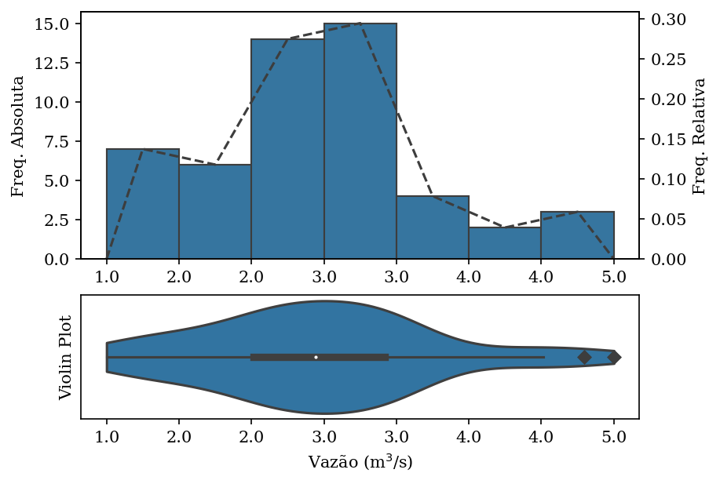

```python
# Frequency polygon
counts, bins_pol = np.histogram(serie_anual["data"], bins=NC)
bins_pol = np.concatenate([np.array([bins_pol[0]]), (bins_pol[:-1] + bins_pol[1:]) / 2, np.array([bins_pol[-1]])])
counts = np.concatenate([np.zeros(1), counts, np.zeros(1)])

q1, q3 = np.percentile(serie_anual["data"], [25, 75])
whisker_low = q1 - (q3 - q1) * 1.5
whisker_high = q3 + (q3 - q1) * 1.5
outliers = serie_anual["data"][(serie_anual["data"] > whisker_high) | (serie_anual["data"] < whisker_low)]

fig, ax = plt.subplots(2, 1, constrained_layout=True, gridspec_kw={"height_ratios":[2, 1]})
ax_right = ax[0].twinx()

n, bins, _ = ax[0].hist(
        x=serie_anual["data"], bins='sturges', color='#36759f', edgecolor='#3d3d3d',
)
ax[0].set_ylabel("Freq. Absoluta")
ax[0].set_xticks(bins)
ax[0].set_xticklabels(bins.round())
ax_right.hist(
        x=serie_anual["data"], bins=len(n), color='#36759f', edgecolor='#3d3d3d',
        weights=np.ones_like(serie_anual["data"].to_numpy())/len(serie_anual["data"]),
)
ax_right.set_ylabel("Freq. Relativa")

ax_right.plot(bins_pol, counts/len(serie_anual["data"]), '--', color='#3d3d3d')

sns.violinplot(x=serie_anual["data"], cut=0, ax=ax[1])
ax[1].set_xticks(bins)
ax[1].set_xticklabels(bins.round())
ax[1].set_yticks([])
ax[1].set_xlabel('Vazão (m$^3$/s)')
ax[1].set_ylabel("Violin Plot")
sns.scatterplot(x=outliers, y=0, marker='D', edgecolor='#3d3d3d', color='#3d3d3d', ax=ax[1])

if salvar:
    fig.savefig('report/plots.png', format='png', dpi=300)
plt.plot()
```